# Lab 1 - pierwszy raport statystyczny

Dzmitry Navumau

February, 2024

Na dzisiejszych zajęciach zapoznamy się ze środowiskiem [Rstudio](https://rstudio.com/) oraz przygotujemy nasz pierwszy raport statystyczny z użyciem pakietu [Rmarkdown](https://rmarkdown.rstudio.com/).

## Rstudio

Uruchom program Rstudio. Jeśli korzystasz z własnego komputera, zainstaluj Rstudio korzystając z linka podanego powyżej. Na komputerach w laboratorium jest już zainstalowny.

Rstudio jest zintegrowanym środowiskiem programistycznym (*integrated development environment, IDE*) służącym do przeprowadzania analiz statystycznych i tworzenia grafiki naukowej przy pomocy pakietu R.

[figure not shown]

*Okno Rstudio*

Środowisko Rstudio składa się z następujących paneli:

- *Edytor*, służący do pisania skryptów,
- *Konsola*, służąca do wywoływania pojedyńczych poleceń,
- *Lista zmiennych* utworzonych przez użytkownika,
- Panel z wykresami.

W zakładkach znajdują się dodatkowe okna, m.in. historia wywołanych poleceń i dokumentacja funkcji i pakietów.

**Zadanie 1.** Utwórz nowy skrypt (*File -> New File -> R Script*) i zapisz go w wybranym katalogu. Następnie wklej do niego wymienione poniżej komendy (każdą w osobnej linijce), wywołaj je po kolei i przyjrzyj się wynikom. Pojedynczą linijkę skryptu możesz wywołać w konsoli wciskając `Ctrl+Enter`, a cały skrypt klikajac przycisk `Source` w prawym górnym rogu okna edytora. Dokładne działanie poszczególnych komend zostanie opisane w dalszej części kursu.

- `data(iris)`, ładuje do pamięci dane o nazwie `iris`. Jest to jeden ze zbiorów danych które są dołączone do pakietu R. Zawiera pomiary kwiatów należących do trzech gatunków rodzaju *Iris* (pol. irys).
- `help(iris)`, wyświetla informacje na temat danych `iris`.
- `View(iris)`, wyświetla dane w oknie edytora.
- `plot(iris$Sepal.Length, iris$Sepal.Width, pch=19, col=iris$Species)`, wykreśla zależność szerokości od długości płatków irysa i koloruje punkty w zależności od gatunku rośliny.
- `legend('topright', legend=levels(iris$Species), fill=1:3)`, dodaje legendę do wykresu.
- `help(mean)`, wyświetla dokumentację funkcji `mean`.
- `tapply(iris$Sepal.Length, iris$Species, mean)`, oblicza średnią długość płatka dla każdego gatunku. Na razie nie musicie przejmować się tym, jak dokładnie działa komenda `tapply()` - zostanie to wyjaśnione w przyszłym tygodniu. Ogólnie rzecz biorąc służy ona do przyłożenia jakiejś funkcji, na przykład `mean()`, do kilku grup obserwacji jednocześnie.

Teraz wywołaj w konsoli komendę `install.packages('tidyverse')`, która zainstaluje pakiet o nazwie `tidyverse`, rozszerzający podstawową funkcjonalność R. Instalacja może trochę potrwać. W tym czasie możesz przeczytać poniższą czytankę.

**Rozwiązanie zadania 1:**

```r
data(iris)
help(iris)
```

```
## запускаю httpd сервер помощи... готово
```

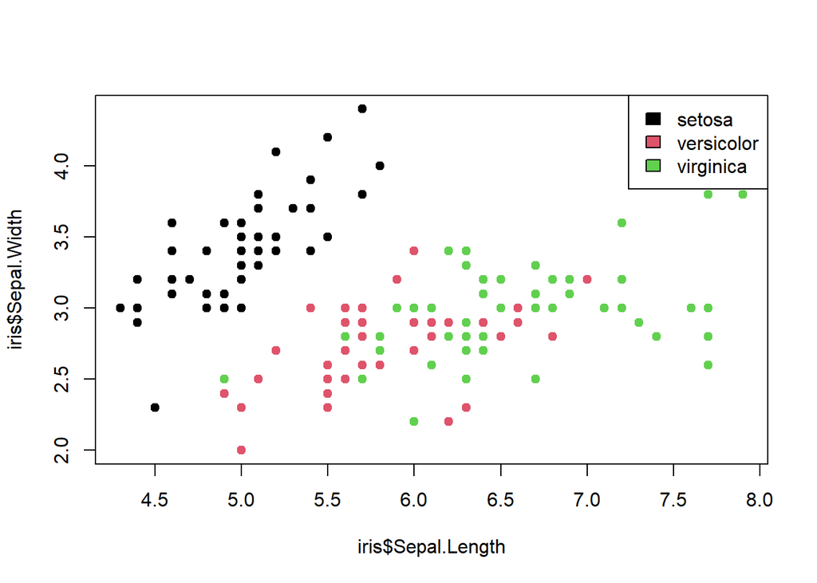

```r
View(iris)
plot(iris$Sepal.Length, iris$Sepal.Width, pch=19, col=iris$Species)
legend('topright', legend=levels(iris$Species), fill=1:3)
```

```r
help(mean)
tapply(iris$Sepal.Length, iris$Species, mean)
```

```
##     setosa versicolor  virginica
##      5.006      5.936      6.588
```

## Co to R i po co to?

R jest jednym z najpopularniejszych programów do analizy danych (obok SAS, Microsoft Excel i języka Python). Jego główną zaletą jest to, że jest mocno przystosowany do szybkiego przeprowadzania prostych analiz z użyciem gotowych pakietów.

Przystosowanie do konkretnego zadania oznacza jednocześnie, że R idzie na przekór większości konwencji spotykanych w innych językach programowania. Z tego powodu, o ile R jest bardzo wygodnym narzędziem do przeprowadzania rutynowych analiz, to implementowanie własnych algorytmów w R jest bardzo uciążliwe i mało wydajne obliczeniowo. Na kursie Statystycznej Analizy Danych nie będziemy prawie nigdy pisać własnych programów - niemal wszystkie zadania da się rozwiązać korzystając z gotowych funkcji i pakietów, które na ogół są napisane w językach FORTRAN lub C.

Głównym konkurentem R jest język Python. Oba narzędzia oferują komplementarne możliwości. O ile R jest wyspecjalizowanym pakietem statystycznym, to język Python jest językiem ogólnego zastosowania. Z tego powodu dużo lepiej nadaje się do implementowania własnych, niestandardowych rozwiązań. Jest również dużo bardziej wydajny obliczeniowo - kod napisany w tym języku wywołuje się kilku(dziesięcio)krotnie szybciej niż analogiczny kod napisany w R. Z drugiej strony, przeprowadzenie typowej analizy i przygotowanie raportu statystycznego zajmuje w nim kilku(dziesięcio)krotnie więcej czasu.

Zarówno R jak i Python są powszechnie używane w analizie danych i każdy, kto planuje w przyszłości pracować z danymi, powinien poznać oba te narzędzia przynajmniej w podstawowym stopniu i wiedzieć, kiedy stosować każde z nich.

## Raporty statystyczne w Rmarkdown

Rmarkdown Notebook służy do łączenia kodu w R z tekstem w języku naturalnym oraz wzorami w języku $\LaTeX$.

[figure not shown]

*Notatnik Markdown*

Komórki z kodem w R zaczynają się od trzech apostrofów (chodzi o tzw. *backticks*, czyli te na klawiszu z tyldą) i litery r w nawiasach klamrowych, a kończą trzema apostrofami.  
Pominięcie litery r oznacza wyróżnioną komórkę z tekstem,

```
taką jak ta.
```

**Zadanie 2.** Utwórz nowy notatnik markdown z domyślnymi ustawieniami (*File -> New File -> R Markdown*) i zapisz go w wybranym katalogu. Utwórz nową komórkę z kodem w R i wklej do niej następujące komendy:

- `data(iris)`
- `head(iris)`, wyświetla kilka pierwszych wierszy tabeli `iris`.

Utwórz kolejną komórkę z kodem i wklej do niej wybrane komendy z Zadania 1. Skompiluj notatnik (przycisk `Knit` na górze okna edytora) i obejrzyj wynik.  
Jeśli pakiet `rmarkdown` nie jest zainstalowny, to powinien zainstalować się automatycznie. Może to trochę potrwać. W tym czasie możesz zapoznać się ze składnią języka Markdown korzystając z [tej ściągawki](https://rstudio.com/wp-content/uploads/2015/02/rmarkdown-cheatsheet.pdf) lub dowolnych innych materiałów wyszukanych samodzielnie w internecie.

## Obsługa danych w R

Podstawowym typem danych w R jest tzw. `data frame`, czyli **ramka danych**. Przykładem takiej zmiennej są dane `iris`. Poszczególne komórki wybieramy za pomocą nawiasów kwadratowych:

- `x <- iris[1,2]` przypisuje zmiennej `x` wartość z pierwszego wiersza i drugiej kolumny. Uwaga: w przeciwieństwie do wielu języków programowania, w R numerację zaczynamy od 1, a nie od 0.
- `x <- iris[1,]` przypisuje zmiennej `x` pierwszy wiersz.
- `x <- iris[,1]` przypisuje pierwszą kolumnę.
- `x <- iris$Sepal.Length` przypisuje kolumnę o nazwie `Sepal.Length`. Uwaga: nie stosujemy cudzysłowu przy nazwie kolumny.

Analogicznie przypisujemy wartości do komórek, wierszy lub kolumn:

- `iris[1,2] <- 1` przypisze $1$ do komórki w pierwszym wierszu i drugiej kolumnie
- `iris$New_column <- 2` utworzy nową kolumnę o nazwie `New_column`, wypełnioną dwójkami.

Liczby wierszy i kolumn tabeli są wyświetlone w oknie z listą zmiennych. Możemy również sprawdzić je za pomocą komend `nrow` oraz `ncol`. Nazwy kolumn możemy sprawdzić komendą `colnames()`.

Kolejny ważny typ danych to **wektor liczb zmiennoprzecinkowych**.  
Przykładem takich wektorów są pierwsze cztery kolumny danych `iris`.  
Nowy wektor długości $n$ wypełniony zerami tworzymy komendą `x <- numeric(n)`.  
Kilka wektorów $x_1, x_2, x_3$ łączymy w nowy wektor $y$ za pomocą komendy `c()` (skrót od *concatenate*): `y <- c(x1, x2, x3)`.  
Długość wektora $x$ sprawdzamy komendą `length(x)`.  
Wektory można do siebie dodawać: `z <- x+y` oraz mnożyć: `z <- x*y`.  
Mnożenie odbywa się po współrzędnych.

**Zadanie 3.** Dołącz do danych `iris` nową kolumnę o nazwie `Sepal.Area`, równą iloczynowi kolumn `Sepal.Length` oraz `Sepal.Width`. **Rozwiazanie Zadania 3:**

```r
iris$Sepal.Area <- iris$Sepal.Length * iris$Sepal.Width
```

Innym typem wektora jest **wektor całkowitoliczbowy**.  
Wektor złożony z kolejnych liczb całkowitych od $n$ do $m$ (włącznie) tworzymy następująco: `x <- n:m`.  
Tego typu wektor możemy wykorzystać do wybrania kilku wierszy tabeli: `x <- iris[5:10, ]`.  
Jeśli chcemy wybrać kilka fragmentów tabeli, możemy wykorzystać komendę `c()`.  
Na przykład, `x <- iris[c(1:10, 20:30), ]` przypisze do zmiennej `x` nową ramkę danych, złożoną z wierszy o numerach od 1 do 10 oraz od 20 do 30.

**Zadanie 4.** Utwórz wektor kolejnych liczb naturalnych od 1 do 1000 włącznie. Następnie:

- Pomnóż każdy element przez 2.
- Zmień co piąty element na 0, korzystając z operatora `:` i działań arytmetycznych.
- Dodaj elementy -2, -1 na początku wektora oraz 2001, 2002 na końcu.
- Sprawdź długość nowego wektora.

**Rozwiazanie zadania 4:**

```r
numbers <- 1:1000
numbers <- numbers * 2
numbers[seq(5, length(numbers), by = 5)] <- 0
numbers <- c(-2, -1, numbers, 2001, 2002)
length(numbers)
```

```
## [1] 1004
```

Bardziej złożone sekwencje liczb możemy tworzyć komendą `seq()`.  
Jej działanie możesz sprawdzić wpisując w konsolę komendę `help(seq)`. Wyświetli ona dokumentację funkcji `seq` w miejscu panelu z wykresami.

Kolejnym ważnym typem zmiennej jest typ *factor*, czyli tzw. typ wyliczeniowy. Jest to wektor obserwacji z ustalonego zbioru wartości, tzw. poziomów.  
Przykładem takiej zmiennej jest piąta kolumna tabeli `iris`.  
Jest to factor o trzech poziomach: `setosa`, `versicolor` oraz `virginica`.  
Ważną cechą factorów jest to, że pamiętają, jakiego typu poziomy mogą w nich wystąpić.  
Widać to na przykład po wybraniu pierwszych trzech wierszy z kolumny `Species`:

```r
trzy_poziomy <- iris[1:3,5]
trzy_poziomy
```

```
## [1] setosa setosa setosa
## Levels: setosa versicolor virginica
```

Pomimo tego, że w nowym wektorze występują jedynie gatunki `setosa`, zmienna `trzy_poziomy` nadal pamięta pierwotny zbiór gatunków Jak się niedługo okaże, jest to niezwykle pomocne w analizie danych.

R posiada jeszcze kilka typów zmiennych, które, w zależności od potrzeb, będą pojawiać się na kolejnych zajęciach.

## Biblioteka ggplot2

Biblioteka `ggplot2` służy do przygotowywania grafiki naukowej w R, i jest jedną z najmocniejszych stron tego języka. Wszystkie wykresy na SAD powinniście przygotowywać z użyciem tej biblioteki. Przed użyciem bibliotekę należy załadować używając komendy `library(ggplot2)`.

Sposób przygotowywania wykresów z użyciem ggplot2 jest dość nietypowy, ale stosunkowo intuicyjny. Na początku tworzymy pusty wykres komendą `ggplot()`. Na tym etapie możemy od razu określić, z jakich danych chcemy korzystać, pisząc np. `ggplot(iris)`.  
Dane muszą być typu *data frame*. Jest to (niemalże) jedyny typ danych obsługiwany przez tę bibliotekę.  
Częstym źródłem błędów przy obsłudze biblioteki ggplot2 jest próba stworzenia wykresu z wektorów liczb zmiennoprzecinkowych.

Na pusty wykres nakładamy kolejne warstwy, takie jak wykres punktowy, liniowy, histogram itd. Każdą taką warstwę tworzymy osobną komendą, zaczynającą się na ogół od `geom` lub od `stat`. Na przykład, `geom_point()` to warstwa zawierająca wykres punktowy. Wszystkie geometrie (czyli typy wykresów) są opisane w dokumentacji pakietu `ggplot2` na [tej stronie](https://ggplot2.tidyverse.org/reference/).

Dodanie nowej warstwy do pustego wykresu wykonujemy poprzez dodanie nowej warstwy do pustego wykresu: `ggplot() + geom_point()`.  
Na końcu musimy jeszcze określić, co konkretnie chcemy wykreślić na wykresie. W `ggplot2` robimy to za pomocą tzw. *estetyk* (*aesthetics*), które określają, w jaki sposób dane mają być przekształcone na własności wizualne na wykresie. Estetyki określają m.in. położenie na osi x i na osi y, kolor, rozmiar i wypełnienie punktów. Możemy określić je globalnie, w funkcji `ggplot()`, lub dla każdej warstwy z osobna.

Zależność szerokości od długości płatków irysów możemy przedstawić na wykresie punktowym w następujący sposób:

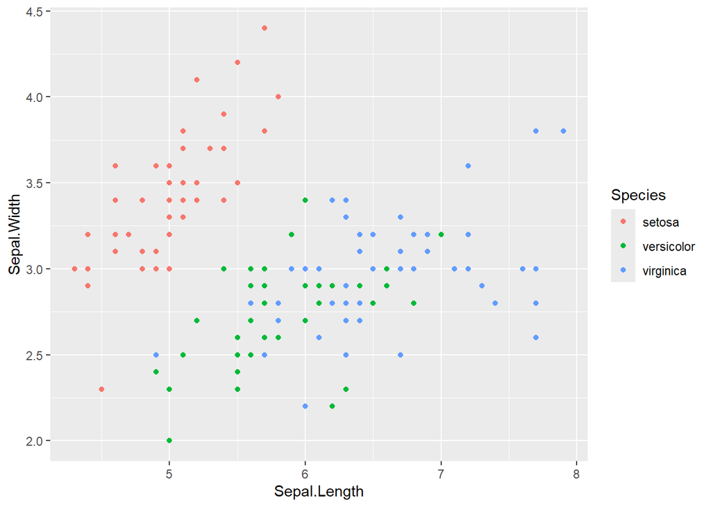

```r
ggplot(iris) + geom_point(aes(x=Sepal.Length, y=Sepal.Width, col=Species))
```

Ważne jest, żeby pamiętać, że w estetykach podajemy nazwy zmiennych bez cudzysłowu. Kolor punktów określamy podając estetykę `col`, w której wystarczy określić, do jakiej grupy należy każda obserwacja. Kolory zostaną dobrane automatycznie.

Dane, z jakich tworzymy wykres, możemy określić albo w funkcji `ggplot()`, albo bezpośrednio w geometrii, na przykład tak:

```r
ggplot() + geom_point(aes(x=Sepal.Length, y=Sepal.Width, col=Species), data=iris)
```

Żeby zmodyfikować ogólny wygląd wykresu, możemy na końcu dodać tzw. *temat* (ang. *theme*). Do grafiki naukowej szczególnie nadaje się `theme_minimal()`:

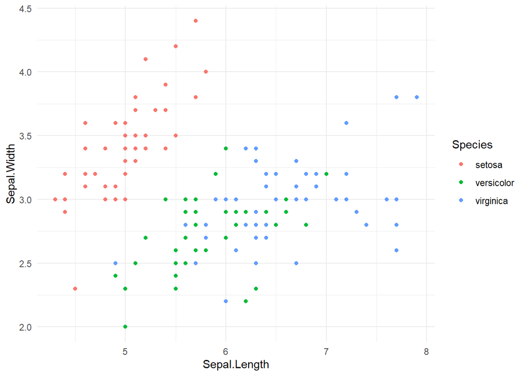

```r
ggplot(iris) + geom_point(aes(x=Sepal.Length, y=Sepal.Width, col=Species)) + theme_minimal()
```

**Zadanie 5.** Utwórz nową kolumnę z kodem w R w notatniku z poprzedniego zadania. Załaduj dane o nazwie `DNase`. Wybierz co drugi wiersz tabeli. Korzystając z biblioteki `ggplot2` oraz geometrii `geom_line`, przedstaw zależność zmiennej `density` od zmiennej `conc` na wykresie liniowym. Dodaj kolejną warstwę z wykresem punktowym obrazującym tę zależność. Zmodyfikuj kształt punktów w wybrany przez siebie sposób (patrz [dokumentacja](https://ggplot2.tidyverse.org/reference/geom_point.html) funkcji geom_point).

**Rozwiązanie zadanie 5:**

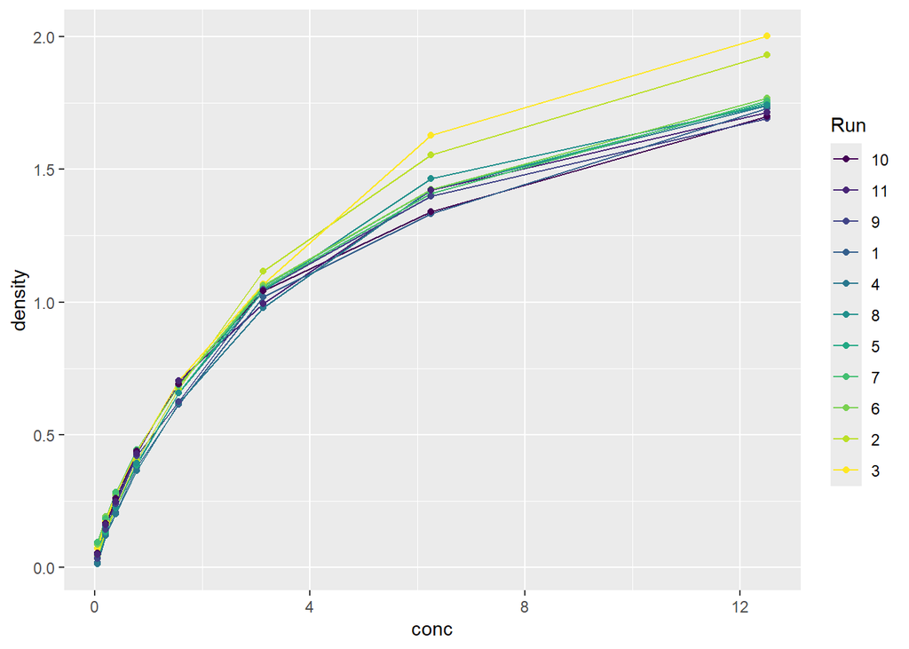

```r
data(DNase, package = "datasets")
filtered_DNase <- DNase[seq(1, nrow(DNase), by = 2), ]

ggplot(filtered_DNase, aes(x = conc, y = density, colour = factor(Run))) +
  geom_line() +
  geom_point(shape = 19) +
  labs(colour = "Run")
```

**Uwaga dotycząca funkcji qplot.** Szukając informacji dotyczących biblioteki ggplot2 w internecie możecie natrafić na funkcję `qplot`. Jest to funkcja służąca do szybkiego tworzenia prostych wykresów. Sposób użycia tej funkcji jest jednak zupełnie inny niż w przypadku standardowych funkcji z biblioteki ggplot2, dlatego na razie nie będziemy z niej korzystać.

## Zadania dodatkowe

**Zadanie 1.** Funkcja `rnorm()` służy do losowania obserwacji z rozkładu normalnego. Wywołanie komendy `help(rnorm)` wyświetli jej dokumentację, wraz z opisem kilku innych funkcji związanych z rozkładem normalnym. Celem tego zadania jest porównanie gęstości rozkładu normalnego z histogramem wylosowanych wartości.

- Utwórz wektor `X` zawierający 200 obserwacji wylosowanych z rozkładu normalnego z parametrami `mean=4`, `sd=2`.
- Przekształć wylosowany wektor w ramkę danych: `X <- data.frame(X)`.
- Utwórz histogram wylosowanych wartości korzystając z biblioteki ggplot2 i geometrii `geom_histogram`. Dokumentację i przykłady zastosowania tej geometrii wyszukaj w internecie. Co znajduje się na osi OY utworzonego wykresu?
- Spraw, żeby na osi OY znalazła się częstość występowania danej wartości. Można to zrobić wykorzystując specjalną estetykę: `aes(y=..density..)`.
- Utwórz wektor zmiennoprzecinkowy `x`, zawierający ciąg liczb od -5 do 15 z odstępem 0.2 (tak, żeby długość wektora `x` wynosiła 101). Możesz wykorzystać funkcję `seq`.
- Utwórz wektor `y`, zawierający wartość gęstości rozkładu normalnego z parametrami `mean=4`, `sd=2` w punktach wektora `x`: `y <- dnorm(x, 4, 2)`. Większość funkcji w R, w tym `dnorm`, przyjmuje jako argument całe wektory i zwraca wynik obliczony dla każdego elementu wektora.
- Połącz wektory `x` i `y` w jedną ramkę danych o nazwie `d`.
- Do histogramu utworzonego w poprzednich punktach dodaj warstwę zawierającą wykres liniowy obrazujący obliczoną gęstość. Pamiętaj, że dane do stworzenia nowej warstwy możesz podać bezpośrednio w geometrii: `geom_line(aes(...), data=d)`.

**Rozwiązanie zadania 1.**

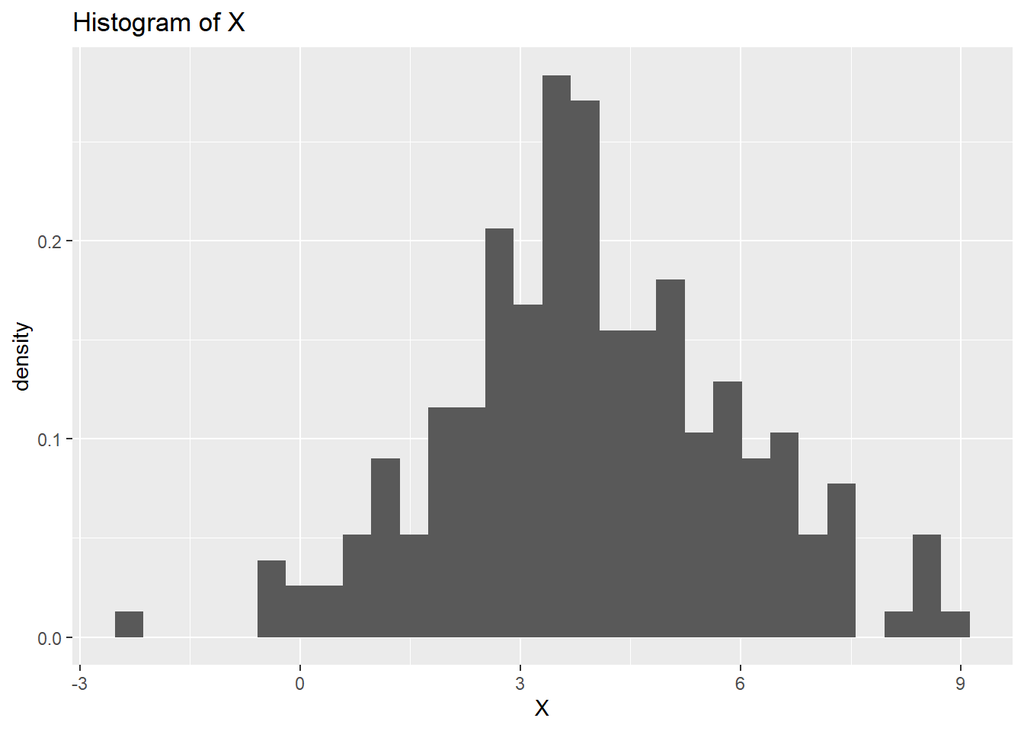

```r
help(rnorm)
X <- rnorm(200, mean = 4, sd = 2)
X <- data.frame(X)

histogram <- ggplot(X, aes(x = X, y = ..density..)) +
  geom_histogram() +
  labs(title = "Histogram of X", x = "X", y = "density")
histogram
```

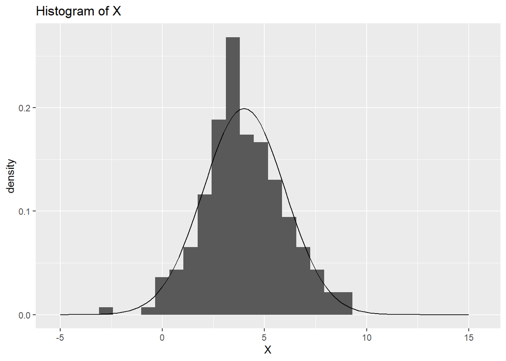

```r
x <- seq(-5, 15, by = 0.2)
y <- dnorm(x, 4, 2)
d <- data.frame(x, y)



histogram_vs_gestosc <- histogram + geom_line(aes(x = x, y = y), data=d)
histogram_vs_gestosc
```

Wywołaj swój kod kilkukrotnie i zobacz, w jaki sposób zmienia się histogram.  
Wypróbuj również kilka wartości parametrów `mean` oraz `sd`.